# Projet séries temporelles linéaires

Antoine Joubrel et Quentin Menner

## Partie I : Les données

### Question 2

1. Nous sommes d’abord demandés si la série avait une saisonnalité. En observant attentivement année après année, on pourrait croire que la série est globalement croissante sur une année. Pour en avoir le coeur nette, nous avons regardé la répartition de l’indice pour chaque mois.

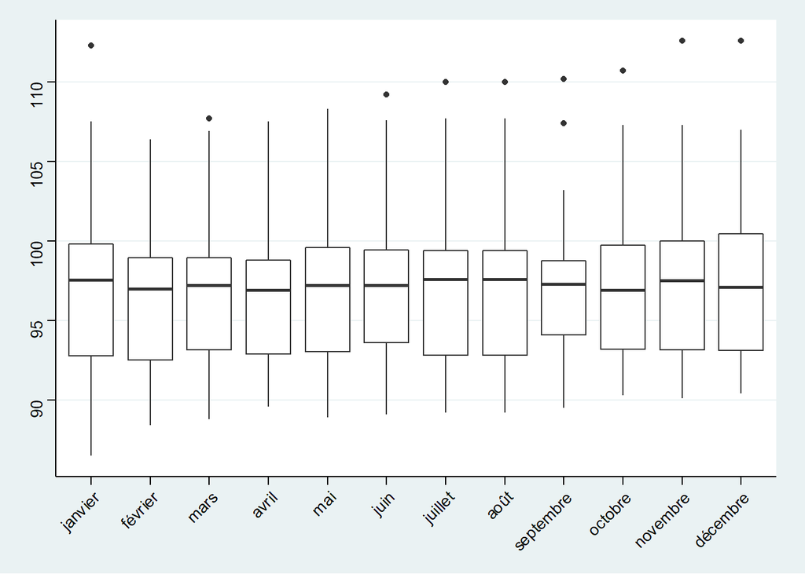

Aucune saisonnalité semble se dégager.

2. Toutefois la série possède une tendance nette à la hausse malgré une baisse de l’indice entre 1990 et 1994.

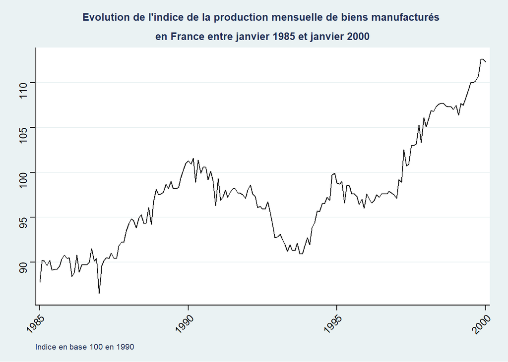

Elle est nette quand on réalise une régression linéaire de la série sur le temps (coefficent de 0.087).

Nous avons donc différencié la série puis réaliser des tests de stationnarité sur cette nouvelle série.

Les test ADF et PP rejette l’hypothèse de racine unité et le test KPSS ne rejette pas l’hypothèse de stationnarité de la série. Nous considérons donc que la série différenciée stationnaire.

### Question 3

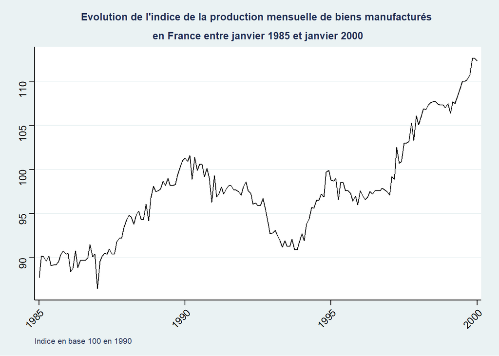

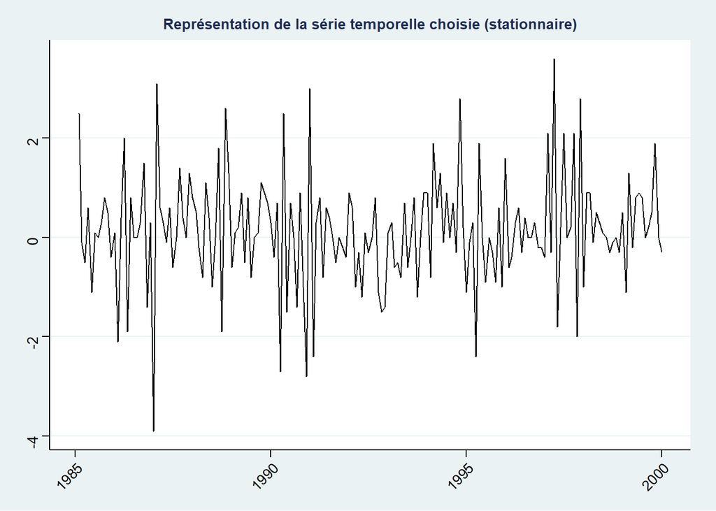

## Partie II : Modèles ARMA

### Question 4

Une caractéristique importante de notre série temporelle est l’autocorrélation des résidues. On observe en effet qu’ils sont linéairement décroissants et en dehors des intervalles de confiance comme il est le cas dans un AR pure. Nous sommes donc amèné à penser que la série est un AR pure.

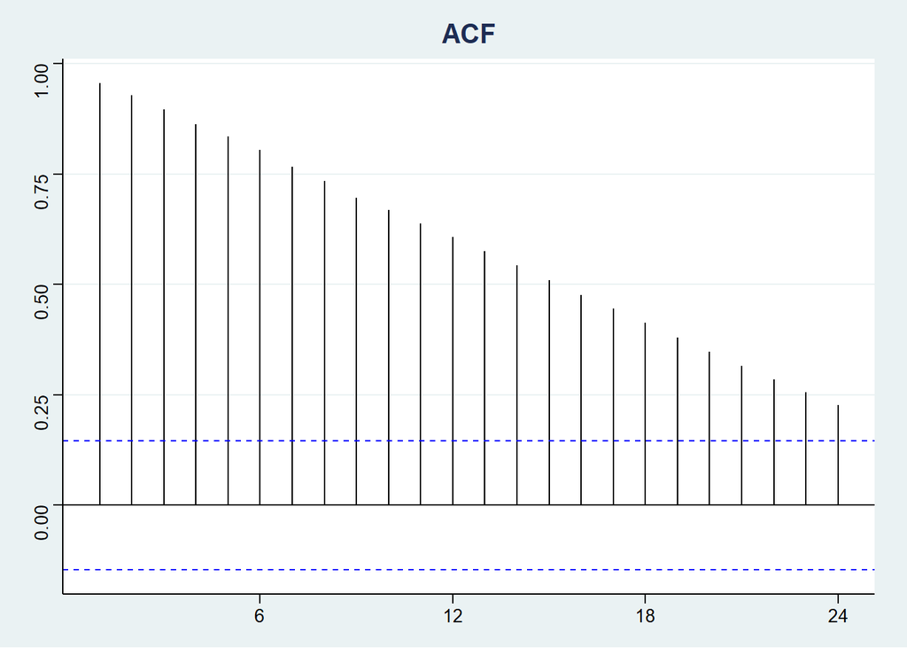

Continuous tout de même la méthode de Box-Jenkins, pour voir si notre hypothèse est vérifiée.

Les graphiques de l’ACF et du PACF donne comme valeur maximale des coeffecients AR et MA 1.

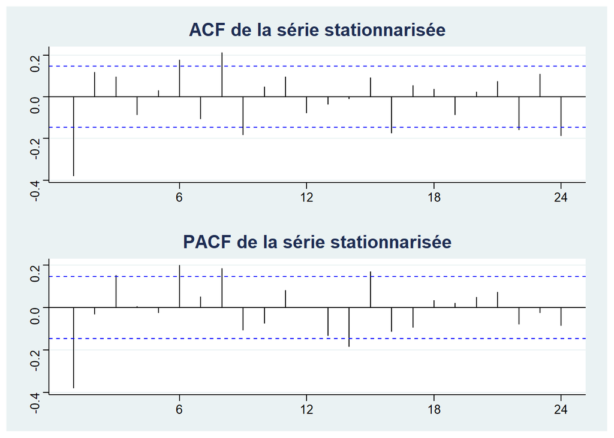

On évalue donc 4 modèles : ARMA(0,0), ARMA(1,0) (ou AR(1)), ARMA(0,1) (ou MA(1)) et ARMA(1,1) en regardant d’abord l’autocorrélation des résidues et la significativité des coefficients.

- Pour le modèle ARMA(0,0) (bruit blanc), on estime le coefficent de la constante

| term | estimate | std.error | statistic | p.value |
| --- | --- | --- | --- | --- |
| intercept | 0.1366667 | 0.08355864 | 1.635578 | 0.101928 |

La constante (seul paramètre) n’est pas significative.

```
##       lag b.statistic b.p.value
##  [1,] 1   NA          NA
##  [2,] 2   29.05626    7.030669e-08
##  [3,] 3   30.76253    2.089307e-07
##  [4,] 4   32.15385    4.856948e-07
##  [5,] 5   32.31955    1.645929e-06
##  [6,] 6   38.24597    3.367374e-07
##  [7,] 7   40.44434    3.725091e-07
##  [8,] 8   48.98071    2.288786e-08
##  [9,] 9   55.46514    3.584941e-09
## [10,] 10  55.90873    8.170861e-09
```

- On procède de même pour le modèle AR(1) :

  | term | estimate | std.error | statistic | p.value |
  | --- | --- | --- | --- | --- |
  | ar1 | -0.3883957 | 0.06942987 | -5.594071 | 2.218057e-08 |
  | intercept | 0.1336629 | 0.05561796 | 2.403233 | 1.625082e-02 |

Les coefficients sont significatifs aux seuils usuels.

```
##       lag b.statistic b.p.value
##  [1,] 1   NA          NA
##  [2,] 2   NA          NA
##  [3,] 3   4.091048    0.04311091
##  [4,] 4   4.720079    0.09441648
##  [5,] 5   5.985802    0.112303
##  [6,] 6   13.86031    0.007754497
##  [7,] 7   14.06167    0.0152224
##  [8,] 8   18.53717    0.005021067
##  [9,] 9   21.7933     0.002757393
## [10,] 10  21.91809    0.005069882
## [11,] 11  24.59587    0.0034523
## [12,] 12  25.77409    0.004056201
## [13,] 13  27.38773    0.004014003
## [14,] 14  27.40036    0.006763869
## [15,] 15  27.70803    0.009937022
```

Est-il valide ? Pour cela, nous avons observé la répartition des résidus.

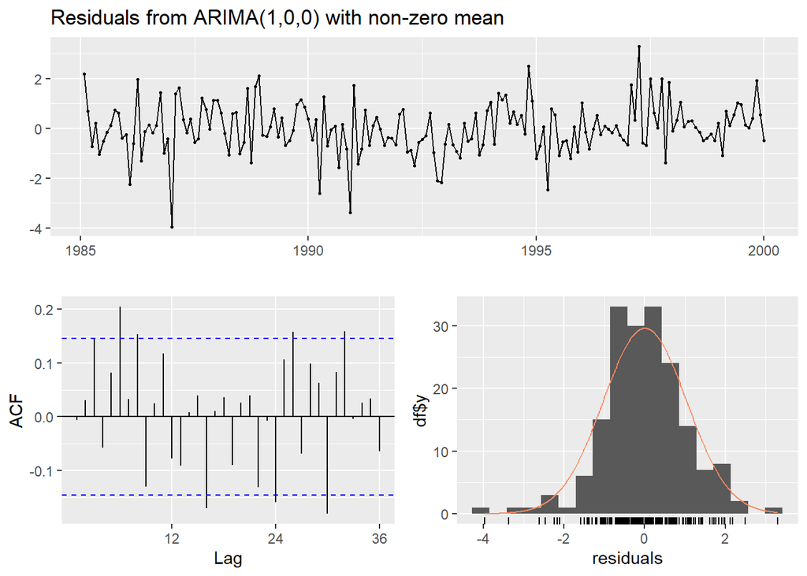

```
##
##  Ljung-Box test
##
## data:  Residuals from ARIMA(1,0,0) with non-zero mean
## Q* = 44.817, df = 22, p-value = 0.002799
##
## Model df: 2.   Total lags used: 24
```

### Question 5

Nous supposons que donc la production mensuelle de biens manufacturés suit un **ARIMA(1,1,0)** car la série avait besoin d’être différencié une fois pour être stationnaire. Le coeffcients lié à l’AR(1) est estimé à **-0.388** et la constante est de **0.134**. La formule de la série est donc :

$$X_t = 0.134 + 0.612X_{t-1} + 0.388X_{t-2} + \epsilon_t$$
avec $\epsilon_t$ un bruit blanc gaussien.

## Partie III : Prévision

### Question 6

Comme nous avons réalisé une différentiation d’un mois à l’autre dans la question 2, nous prenons ici le modèle AR(1) de la forme suivante :
$$\begin{align*}
\Delta X_{t+1} &= a_{0} \Delta X_{t} + \epsilon_{t} \\
X_{t+1} &= (a_{0}+1)X_{t} - a_{0}X_{t-1} + \epsilon_{t}
\end{align*}$$
Avec $(\epsilon_{t})_{t} \sim {\sf Norm}(0,1)$. Avec une probabilité de $\alpha\%$, $q_{\frac{\alpha}{2}} \leq \mid\epsilon_{t}\mid \leq q_{1-\frac{\alpha}{2}}$. Ce qui donne :

$$\begin{align*}
q_{\frac{\alpha}{2}} + (a_{0}+1)X_{T} - a_{0}X_{T-1} \leq &X_{T+1} \leq q_{1-\frac{\alpha}{2}} + (a_{0}+1)X_{T} - a_{0}X_{T-1} \\ \\
\text{Et : } q_{\frac{\alpha}{2}} + (a_{0}+1)X_{T+1} - a_{0}X_{T} \leq &X_{T+2} \leq q_{1-\frac{\alpha}{2}} + (a_{0}+1)X_{T+1} - a_{0}X_{T} \\
q_{\frac{\alpha}{2}} + (a_{0}+1)(q_{\frac{\alpha}{2}} + (a_{0}+1)X_{T} - a_{0}X_{T-1}) - a_{0}X_{T} \leq &X_{T+2} \leq q_{1-\frac{\alpha}{2}} + (a_{0}+1)(q_{1-\frac{\alpha}{2}} + (a_{0}+1)X_{T} - a_{0}X_{T-1}) - a_{0}X_{T} \\
(a_{0}+2)q_{\frac{\alpha}{2}} + (a_{0}^2+a_{0}+1)X_{T} - a_{0}(a_{0}+1)X_{T-1} \leq &X_{T+2} \leq (a_{0}+2)q_{1-\frac{\alpha}{2}} + (a_{0}^2+a_{0}+1)X_{T} - a_{0}(a_{0}+1)X_{T-1} \\
\end{align*}$$

D’après la partie II, $a_{0} = -0,388$. Donc on a comme région de confiance de niveau $\alpha$:

$X_{T+1} \in \left[q_{\frac{\alpha}{2}} + 0.612X_{T} + 0.388X_{T-1}, q_{1-\frac{\alpha}{2}} + 0.612X_{T} + 0.388X_{T-1}\right]$

Et : $X_{T+2} \in \left[q_{\frac{\alpha}{2}} + 0.612X_{T+1} + 0.388X_{T}, q_{1-\frac{\alpha}{2}} + 0.612X_{T+1} + 0.388X_{T}\right]$

Ce qui donne comme interval de confiance pour $X_{t+2}$: $X_{T+2} \in \left[1.612q_{\frac{\alpha}{2}} + 0.762544X_{T} + 0.237456X_{T-1}, 1.612q_{1-\frac{\alpha}{2}} + 0.762544X_{T} + 0.237456X_{T-1}\right]$

### Question 7

Pour obtenir cette région de confiance, nous utilisons les hypothèses que les résidus suivent une loi normale centrée réduite, que la série temporelle est considérée comme stationnaire une fois la différenciation effectuée et qu’elle peut être modélisée par un modèle ARIMA de paramètres (1,1,0).

### Question 8

Cela nous donne la région de confiance suivante pour $X_{T+2}$ en fonction de $X_{T+1}$ :

[figure not shown]

### Question 9

On cherche à déterminer une méthode permettant de prédire à $X_{T+1}$ à partir d’une autre série $(Y_{t})_{1 \leq t \leq T+1}$ et plus précisément de sa valeur à la T+1ème période $Y_{T+1}$.

On sait que $(Y_{t})_{1 \leq t \leq T+1}$ est une série stationnaire. De même dans notre cas, $(\Delta X_{t})_{t}$ est aussi stationnaire. Comme on considère que l’on a $Y_{T+1}$ avant $X_{T+1}$, on peut donc réaliser la régression suivante :
$$\begin{align*}
\Delta X_{T+1} &= \beta Y_{T+1} + c + u_{t} \\
X_{T+1} &= \beta Y_{T+1} + X_{T} + c + u_{t} \\
\text{Avec : }\beta &= \frac{Cov(X_{t},Y_{t})}{Var(X_{t})} \\
\text{et }c &= EY_{t}-\beta EX_{t} \\
\end{align*}$$
Pour pouvoir réaliser cette régression il faut s’assurer que la condition suivante est respectée :
$$\begin{align*}
\beta \neq 0 &\iff Cov(X_{t},Y_{t}) \neq 0 \\
\end{align*}$$
On doit en plus considérer comme condition que les observations sont comme un échantillon donc que l’écart type estimé de $\hat{\beta}_{n}$ notée $se_{n}$ est juste ce qui ne serait pas le cas normalement. Dans ce cas, on peut réaliser un test de $H_{0} : \beta = 0$ contre $H_{1} : \beta \neq 0$. Pour tester $H_{0}$ au niveau $\alpha$, nous considérons la t-statistique $t_{n}=\frac{\hat{\beta}_{n}}{se_{n}}$ et la région critique : $W_{\alpha}=\{\mid t_{j} \mid > q_{1-\frac{\alpha}{2}}\},$ où $q_{1-\frac{\alpha}{2}}$ est le quantile d’ordre $1-\frac{\alpha}{2}$ de $N(0,1)$.